# PPCA0026 - Tarefa de Casa: Validação Cruzada e Bootstrap

- Show All Code
- Hide All Code
- View Source

Análise de SVM e k-NN no dataset Iris

Author

Ítalo Vinícius Pereira Guimarães / Sílvio Ferreira Gomes Júnior

Published

June 20, 2025

**Prazo de Entrega:** 2025-06-29 23:59

## Introdução

Nesta tarefa, você aplicará os conceitos de Validação Cruzada (CV) e Bootstrap para selecionar e avaliar modelos de classificação. O objetivo é ir além da simples aplicação de funções prontas, focando na implementação dos mecanismos subjacentes para garantir um entendimento profundo dos métodos.

**Objetivos de Aprendizagem:**

1. Observar a instabilidade da abordagem de validação com uma única divisão (treino/validação).
2. Implementar um loop de 5-fold Cross-Validation estratificado para selecionar hiperparâmetros para modelos SVM e k-NN.
3. Visualizar os resultados da busca por hiperparâmetros usando heatmaps e gráficos de slice.
4. Utilizar o Bootstrap em um conjunto de teste para quantificar a incerteza na estimativa do erro dos modelos finais.
5. Comparar modelos de forma robusta, analisando a distribuição dos seus rankings de performance sob reamostragem.

**Instruções Gerais:**

- Este arquivo serve como template. Você deve preencher as seções marcadas com seu código, saídas e respostas.
- Para esta tarefa, usaremos o pacote `e1071` para SVM, `class` para k-NN, e o `tidyverse` para manipulação de dados e gráficos.
- **Entrega:** Envie dois arquivos: este `.qmd` completo e o arquivo `.html` auto-contido resultante.

## 0. O Problema da Variabilidade de uma Única Divisão

### Tarefa 0

```r
# install.packages(c("tidyverse", "class", "e1071", "caret"), dependencies = TRUE)
```

```r
# Carregar pacotes
library(tidyverse)
library(class) # Para knn()
library(e1071) # Para svm()
library(caret) # Para createDataPartition

# Filtrar o dataset iris para as duas espécies
iris_duas_classes <- iris %>%
  filter(Species %in% c("versicolor", "virginica")) %>%
  mutate(Species = factor(Species)) # Recodifica os fatores para remover 'setosa'
```

```r
# Vetor de sementes para testar
sementes <- c(1, 42, 123)
erros_validacao <- c() # Vetor para armazenar os erros

for (semente_atual in sementes) {
  set.seed(semente_atual)

  # Criando uma divisão 80/20 estratificada (exemplo com caret)
  indices_treino_static <- createDataPartition(iris_duas_classes$Species, p = 0.8, list = FALSE)
  treino_static <- iris_duas_classes[indices_treino_static, ]
  validacao_static <- iris_duas_classes[-indices_treino_static, ]

  # Treinar e avaliar o modelo k-NN com k=5
  previsoes_knn <- knn(
    train = treino_static[, 1:4],
    test = validacao_static[, 1:4],
    cl = treino_static$Species,
    k = 5
  )
  erro <- mean(previsoes_knn != validacao_static$Species)
  erros_validacao <- c(erros_validacao, erro)
  cat(paste("Semente:", semente_atual, "- Erro de Validação:", round(erro, 4), "\n"))
}
```

```
Semente: 1 - Erro de Validação: 0
Semente: 42 - Erro de Validação: 0.05
Semente: 123 - Erro de Validação: 0.1
```

**Análise da Tarefa 0:**

Podemos perceber que, conforme a semente muda, os erros de validação também mudam. Isso demonstra a variabilidade da abordagem de validação com uma única divisão, no qual o modelo pode ser sensível à forma como os dados são divididos.

## Parte 1: Validação Cruzada para Seleção de Modelos

### 1.1 Preparação dos Dados

```r
# Divisão 70/30 estratificada para treino e teste
set.seed(2025) # Semente fixa para a tarefa principal

indices_treino <- createDataPartition(iris_duas_classes$Species, p = 0.7, list = FALSE)
iris_treino <- iris_duas_classes[indices_treino, ]
iris_teste <- iris_duas_classes[-indices_treino, ]

cat(paste("Tamanho do conjunto de treino:", nrow(iris_treino), "\n"))
```

```
Tamanho do conjunto de treino: 70
```

```r
cat(paste("Tamanho do conjunto de teste:", nrow(iris_teste), "\n"))
```

```
Tamanho do conjunto de teste: 30
```

### 1.2 Seleção de Modelo SVM com 5-Fold CV

**Exemplo de Uso do `svm()`:** Para ajudá-lo(a) a construir seu loop de CV, o bloco de código abaixo demonstra como treinar um modelo `svm`, fazer previsões e calcular o erro. Você precisará adaptar esta lógica para o seu loop, usando seus dados de `treino_cv` e `validacao_cv` em cada iteração.

```r
# Este é um exemplo em uma única divisão (NÃO é a sua tarefa de CV)
# Use esta sintaxe como guia para o que vai DENTRO do seu loop de CV

# 1. Dados de exemplo (usando a mesma divisão 70/30 de antes)
dados_treino_exemplo <- iris_treino
dados_validacao_exemplo <- iris_teste

# 2. Treinar um modelo SVM com parâmetros específicos
modelo_svm_exemplo <- svm(
  Species ~ .,
  data = dados_treino_exemplo,
  kernel = "radial",
  cost = 1,    # Exemplo de valor de cost
  gamma = 0.5  # Exemplo de valor de gamma
)

# 3. Fazer previsões no conjunto de validação
previsoes_exemplo <- predict(modelo_svm_exemplo, newdata = dados_validacao_exemplo)

# 4. Calcular a taxa de erro
tabela_confusao <- table(Observado = dados_validacao_exemplo$Species, Previsto = previsoes_exemplo)
print(tabela_confusao)
```

```
            Previsto
Observado    versicolor virginica
  versicolor         14         1
  virginica           1        14
```

```r
taxa_erro <- mean(previsoes_exemplo != dados_validacao_exemplo$Species)
cat(paste("\nTaxa de Erro no exemplo:", round(taxa_erro, 4), "\n"))
```

```
Taxa de Erro no exemplo: 0.0667
```

```r
set.seed(2025)

# 1. Defina a Grade de Busca (use a função expand.grid())

# Definindo a grade de hiperparâmetros
grid_svm <- expand.grid(
  cost = c(0.1, 1, 10,100),
  gamma = c(0.01, 0.1, 1,10)
)

# 2. Crie os 5 folds estratificados a partir de `iris_treino`

# Criando os folds estratificados

folds <- createFolds(iris_treino$Species, k = 5, list = TRUE, returnTrain = FALSE)

# Loop para verificar a estratificação em cada fold
for (fold_name in names(folds)) {
  fold_indices <- folds[[fold_name]]

  # Dividir os dados em treino e validação para esta iteração
  treino_cv <- iris_treino[-fold_indices, ]
  validacao_cv <- iris_treino[fold_indices, ]

  # Imprimir o nome do fold e as proporções para verificação
  cat("\n--- Verificando", fold_name, "---\n")
  cat("Proporção no conjunto de treino do fold:\n")
  print(round(prop.table(table(treino_cv$Species)) * 100, 1))
  cat("Proporção no conjunto de validação do fold:\n")
  print(round(prop.table(table(validacao_cv$Species)) * 100, 1))
}
```

```
--- Verificando Fold1 ---
Proporção no conjunto de treino do fold:

versicolor  virginica
        50         50
Proporção no conjunto de validação do fold:

versicolor  virginica
        50         50

--- Verificando Fold2 ---
Proporção no conjunto de treino do fold:

versicolor  virginica
        50         50
Proporção no conjunto de validação do fold:

versicolor  virginica
        50         50

--- Verificando Fold3 ---
Proporção no conjunto de treino do fold:

versicolor  virginica
        50         50
Proporção no conjunto de validação do fold:

versicolor  virginica
        50         50

--- Verificando Fold4 ---
Proporção no conjunto de treino do fold:

versicolor  virginica
        50         50
Proporção no conjunto de validação do fold:

versicolor  virginica
        50         50

--- Verificando Fold5 ---
Proporção no conjunto de treino do fold:

versicolor  virginica
        50         50
Proporção no conjunto de validação do fold:

versicolor  virginica
        50         50
```

```r
# 3. Loop de 5-Fold CV

#criando um loop para cada parametro do grid_svm

resultados_cv <- data.frame() # DataFrame para armazenar os resultados

for (i in 1:nrow(grid_svm)) {
  cost_atual <- grid_svm$cost[i]
  gamma_atual <- grid_svm$gamma[i]

  # Inicializando um vetor para armazenar os erros de validação
  erros_validacao <- c()

  for (fold in folds) {
    # Dividir os dados em treino e validação
    treino_cv <- iris_treino[- fold, ]
    validacao_cv <- iris_treino[fold, ]

    # Treinar o modelo SVM
    modelo_svm_cv <- svm(
      Species ~ .,
      data = treino_cv,
      kernel = "radial",
      cost = cost_atual,
      gamma = gamma_atual
    )

    # Fazer previsões no conjunto de validação
    previsoes_cv <- predict(modelo_svm_cv, newdata = validacao_cv)

    # Calcular a taxa de erro
    erro_cv <- mean(previsoes_cv != validacao_cv$Species)
    erros_validacao <- c(erros_validacao, erro_cv)
  }

  # Armazenar os resultados
  resultados_cv <- rbind(resultados_cv, data.frame(cost = cost_atual, gamma = gamma_atual, erro_validacao = mean(erros_validacao)))
}

# 4. Calcule o erro médio de CV para cada par de hiperparâmetros e mostre em uma tabela do menor para o maior erro
resultados_cv <- resultados_cv %>%
  arrange(erro_validacao)

print(resultados_cv)
```

```
    cost gamma erro_validacao
1    1.0  0.10     0.04285714
2    1.0  0.01     0.05714286
3   10.0  0.01     0.05714286
4  100.0  0.01     0.07142857
5   10.0  0.10     0.07142857
6    1.0  1.00     0.07142857
7    0.1  0.10     0.08571429
8   10.0  1.00     0.08571429
9  100.0  1.00     0.08571429
10   0.1  0.01     0.10000000
11 100.0  0.10     0.10000000
12   0.1  1.00     0.11428571
13  10.0 10.00     0.35714286
14 100.0 10.00     0.35714286
15   1.0 10.00     0.38571429
16   0.1 10.00     0.40000000
```

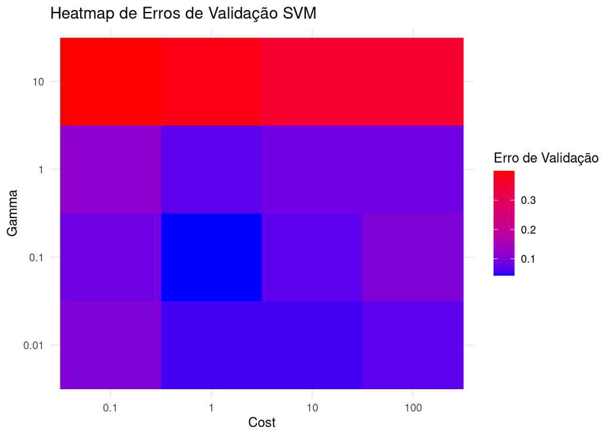

```r
# 5. Visualize os resultados (heatmap e gráfico de slice)


#grafico de heatmap para os resultados dos erros de validacao para cada grid

library(ggplot2)
ggplot(resultados_cv, aes(x = factor(cost), y = factor(gamma), fill = erro_validacao)) +
  geom_tile() +
  scale_fill_gradient(low = "blue", high = "red") +
  labs(title = "Heatmap de Erros de Validação SVM", x = "Cost", y = "Gamma", fill = "Erro de Validação") +
  theme_minimal()
```

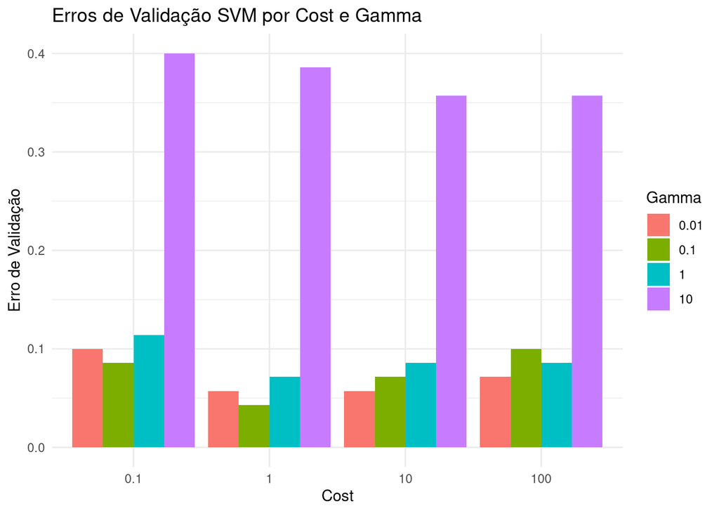

```r
#gráfico de slice para os resultados dos erros de validacao para cada grid
ggplot(resultados_cv, aes(x = factor(cost), y = erro_validacao, fill = factor(gamma))) +
  geom_bar(stat = "identity", position = "dodge") +
  labs(title = "Erros de Validação SVM por Cost e Gamma", x = "Cost", y = "Erro de Validação", fill = "Gamma") +
  theme_minimal()
```

**Análise da Tarefa 1.2:**

Inicialmente já conseguimos observar que a função createFolds do Caret já divide os folds de maneira estratificada matendo a proporção quantitativa das labels (species).

Pelos resultados, podemos observar que o melhor modelo foi aquele que obteve (cost=1 e gamma=0.1), com um erro médio de validação de 0,042. Isso indica que o modelo SVM com esses hiperparâmetros teve a melhor performance na validação cruzada.

### 1.3 Seleção de Modelo k-NN com 5-Fold CV

```r
set.seed(2025)

# hiperparametros do knn, de 1 a 30 sendo somente números impares
k_values <- seq(1, 30, by = 2)

# 2. Crie os 5 folds estratificados a partir de `iris_treino`

# Criando os folds estratificados
folds_knn <- createFolds(iris_treino$Species, k = 5, list = TRUE, returnTrain = FALSE)

# 3. Loop de 5-Fold CV

#criando um loop para cada parametro knn
resultados_knn_cv <- data.frame() # DataFrame para armazenar os resultados

for (k in k_values) {

  erros_validacao_knn <- c()

  for (fold in folds_knn) {
    # Dividir os dados em treino e validação
    treino_cv_knn <- iris_treino[- fold, ]
    validacao_cv_knn <- iris_treino[fold, ]

    # Treinar o modelo k-NN
    previsoes_knn_cv <- knn(
      train = treino_cv_knn[, 1:4],
      test = validacao_cv_knn[, 1:4],
      cl = treino_cv_knn$Species,
      k = k
    )

    # Calcular a taxa de erro
    erro_cv_knn <- mean(previsoes_knn_cv != validacao_cv_knn$Species)
    erros_validacao_knn <- c(erros_validacao_knn, erro_cv_knn)
  }

  # Armazenar os resultados
  resultados_knn_cv <- rbind(resultados_knn_cv, data.frame(k = k, erro_validacao = mean(erros_validacao_knn)))
}

# 4. Calcule o erro médio de CV para cada par de hiperparâmetros e mostre em uma tabela do menor para o maior erro
resultados_knn_cv <- resultados_knn_cv %>%
  arrange(erro_validacao)

print(resultados_knn_cv)
```

```
    k erro_validacao
1   7     0.01428571
2   9     0.01428571
3  11     0.01428571
4  13     0.02857143
5  15     0.02857143
6  17     0.04285714
7  19     0.04285714
8  27     0.04285714
9   1     0.05714286
10  3     0.05714286
11 21     0.05714286
12 23     0.05714286
13 25     0.05714286
14  5     0.07142857
15 29     0.08571429
```

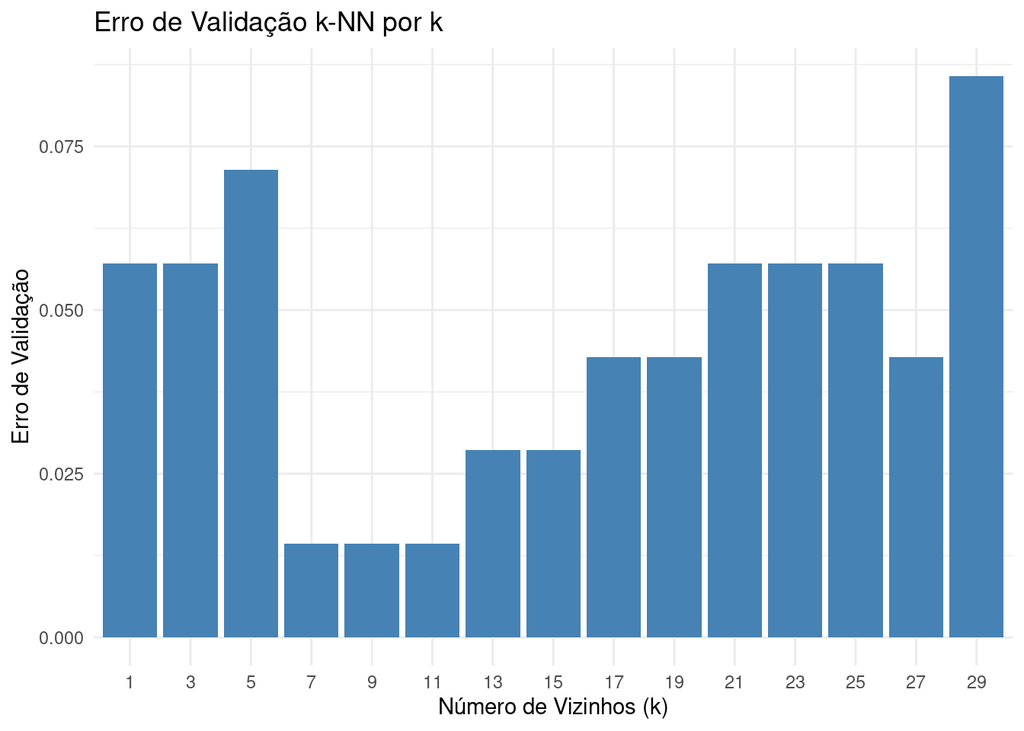

```r
# 5. Criar um gráfico de barras mostrando o erro de validacao médio para cada valor de k
ggplot(resultados_knn_cv, aes(x = factor(k), y = erro_validacao)) +
  geom_bar(stat = "identity", fill = "steelblue") +
  labs(title = "Erro de Validação k-NN por k", x = "Número de Vizinhos (k)", y = "Erro de Validação") +
  theme_minimal()
```

**Análise da Tarefa 1.3:**

De acordo com os resultados, podemos observar que os melhores modelos (7, 9 ou 11 de k) possuem erro de validação por volta de 0,0142. Dessa forma, pensando sempre em buscar aquele com menor complexidade, o melhor modelo k-NN seria aquele com k=11.

### 1.4 Análise Final dos Modelos e Erro de Teste

```r
# Os dois melhores modelos svm tiveram seus parâmetros iguais a cost=1/gamma=0,1 e cost=1/gamma=0,01, e os dois melhores modelos knn tiveram seus parâmetros iguais a k=7 e k=9.

#Criando os modelos finais com os melhores parâmetros encontrados utilizando toda base de treinamento
modelo_svm_final1 <- svm(
  Species ~ .,
  data = iris_treino,
  kernel = "radial",
  cost = 1,
  gamma = 0.1
)
modelo_svm_final2 <- svm(
  Species ~ .,
  data = iris_treino,
  kernel = "radial",
  cost = 1,
  gamma = 0.01
)

modelo_knn_final1 <- knn(
  train = iris_treino[, 1:4],
  test = iris_teste[, 1:4],
  cl = iris_treino$Species,
  k = 9
)

modelo_knn_final2 <- knn(
  train = iris_treino[, 1:4],
  test = iris_teste[, 1:4],
  cl = iris_treino$Species,
  k = 11
)

#calculando o erro médio de teste para os modelos finais
previsoes_svm_final1 <- predict(modelo_svm_final1, newdata = iris_teste)
previsoes_svm_final2 <- predict(modelo_svm_final2, newdata = iris_teste)
previsoes_knn_final1 <- modelo_knn_final1
previsoes_knn_final2 <- modelo_knn_final2



erro_svm_final1 <- mean(previsoes_svm_final1 != iris_teste$Species)
erro_svm_final2 <- mean(previsoes_svm_final2 != iris_teste$Species)
erro_knn_final1 <- mean(previsoes_knn_final1 != iris_teste$Species)
erro_knn_final2 <- mean(previsoes_knn_final2 != iris_teste$Species)

# Crie uma tabela comparando o erro estimado por CV e o erro de teste final para cada um dos quatro modelos
resultados_finais <- data.frame(
  Modelo = c("SVM1 (cost=1, gamma=0.1)", "SVM2 (cost=1, gamma=0.01)", "k-NN1 (k=9)", "k-NN2 (k=11)"),
  Erro_CV = c(0.042, 0.057, 0.0142, 0.0142), # Erros médios de CV
  Erro_Teste = c(erro_svm_final1, erro_svm_final2, erro_knn_final1, erro_knn_final2)
)

print(resultados_finais)
```

```
                     Modelo Erro_CV Erro_Teste
1  SVM1 (cost=1, gamma=0.1)  0.0420 0.06666667
2 SVM2 (cost=1, gamma=0.01)  0.0570 0.03333333
3               k-NN1 (k=9)  0.0142 0.06666667
4              k-NN2 (k=11)  0.0142 0.06666667
```

**Análise da Tarefa 1.4:**

A tabela mostra um ponto interessante quando estudamos a área de machine learning: embora a validação cruzada (Erro_CV) seja considerada a ferramenta padrão para estimar o erro de teste e ajudar na seleção do modelo, os desempenhos calculadas por ela não garante o melhor resultado no conjunto de teste final (Erro_Teste). A discrepância ocorre porque o CV, sendo uma estimativa baseada em divisões aleatórias dos dados de treino, possui sua própria variabilidade e pode levar à escolha de um modelo que se ajustou excessivamente bem à base de treinamento. No caso desta tarefa, os modelos k-NN provavelmente se superajustaram (overfitting) aos dados de treino, alcançando um bom Erro_CV, enquanto o modelo SVM2, apesar de possuir um Erro_CV maior, generalizou melhor para os dados de teste, que são completamente novos. Portanto, o Erro_Teste é a métrica definitiva de desempenho, e o modelo SVM2 é a melhor escolha, pois demonstrou a maior capacidade de generalização.

## Parte 2: Bootstrap para Quantificar a Incerteza

### 2.1 Gerando Amostras Bootstrap

```r
#criando um código para gerar 1000 amostras de bootstrap do conjunto de teste. Cada amostra bootstrap tem o mesmo tamanho do conjunto de teste original criada com resposição
set.seed(2025) # Semente fixa para reprodutibilidade
n_bootstrap <- 1000
amostras_bootstrap <- replicate(n_bootstrap, iris_teste[sample(1:nrow(iris_teste), replace = TRUE), ], simplify = FALSE)
```

### 2.2 Análise da Distribuição do Erro

```r
# criando uma estrutura de dados tipo dataframe com as colunas id_bootstrap,modelo e erro, para armazenar os resultados.
resultados_bootstrap <- data.frame(id_bootstrap = integer(), modelo = character(), erro = numeric())

# cada uma das 1000 amostras bootstrap calculamos a taxa de erro de cada um dos quatro modelos finalistas

for (i in 1:n_bootstrap) {
  amostra_atual <- amostras_bootstrap[[i]]

  # Previsões para os modelos SVM
  previsoes_svm1 <- predict(modelo_svm_final1, newdata = amostra_atual)
  previsoes_svm2 <- predict(modelo_svm_final2, newdata = amostra_atual)

  # Previsões para os modelos k-NN
  previsoes_knn1 <- knn(
    train = iris_treino[, 1:4],
    test = amostra_atual[, 1:4],
    cl = iris_treino$Species,
    k = 9
  )

  previsoes_knn2 <- knn(
    train = iris_treino[, 1:4],
    test = amostra_atual[, 1:4],
    cl = iris_treino$Species,
    k = 11
  )

  # Calculando os erros
  erro_svm1 <- mean(previsoes_svm1 != amostra_atual$Species)
  erro_svm2 <- mean(previsoes_svm2 != amostra_atual$Species)
  erro_knn1 <- mean(previsoes_knn1 != amostra_atual$Species)
  erro_knn2 <- mean(previsoes_knn2 != amostra_atual$Species)

  # Armazenando os resultados
  resultados_bootstrap <- rbind(resultados_bootstrap, data.frame(
    id_bootstrap = i,
    modelo = "SVM1 (cost=1, gamma=0.1)",
    erro = erro_svm1
  ))

  resultados_bootstrap <- rbind(resultados_bootstrap, data.frame(
    id_bootstrap = i,
    modelo = "SVM2 (cost=1, gamma=0.01)",
    erro = erro_svm2
  ))

  resultados_bootstrap <- rbind(resultados_bootstrap, data.frame(
    id_bootstrap = i,
    modelo = "k-NN1 (k=9)",
    erro = erro_knn1
  ))

  resultados_bootstrap <- rbind(resultados_bootstrap, data.frame(
    id_bootstrap = i,
    modelo = "k-NN2 (k=11)",
    erro = erro_knn2
  ))
}

# calculando um intervalo de confianca de 95% para cada modelo usando método de quantis
intervalos_confianca <- resultados_bootstrap %>%
  group_by(modelo) %>%
  summarise(
    erro_medio = mean(erro),
    ic_inf = quantile(erro, 0.025),
    ic_sup = quantile(erro, 0.975)
  )

print(intervalos_confianca)
```

```
# A tibble: 4 × 4
  modelo                    erro_medio ic_inf ic_sup
  <chr>                          <dbl>  <dbl>  <dbl>
1 SVM1 (cost=1, gamma=0.1)      0.0677      0  0.167
2 SVM2 (cost=1, gamma=0.01)     0.0342      0  0.1
3 k-NN1 (k=9)                   0.0677      0  0.167
4 k-NN2 (k=11)                  0.0677      0  0.167
```

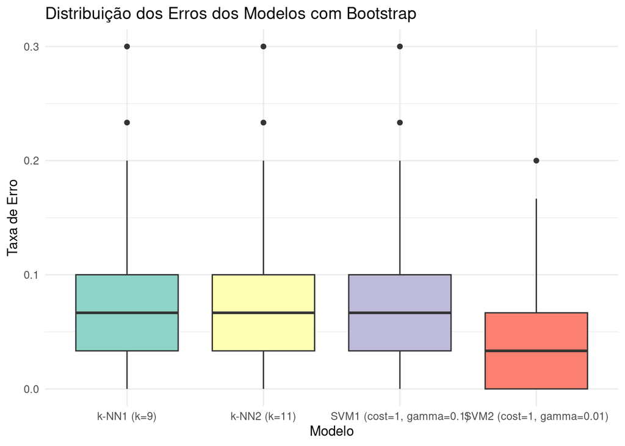

```r
# Criando box-plot para comparar visualmente as distribuições das taxas de erro dos quatro modelos

ggplot(resultados_bootstrap, aes(x = modelo, y = erro, fill = modelo)) +
  geom_boxplot() +
  labs(title = "Distribuição dos Erros dos Modelos com Bootstrap", x = "Modelo", y = "Taxa de Erro") +
  theme_minimal() +
  scale_fill_brewer(palette = "Set3") +
  theme(legend.position = "none")
```

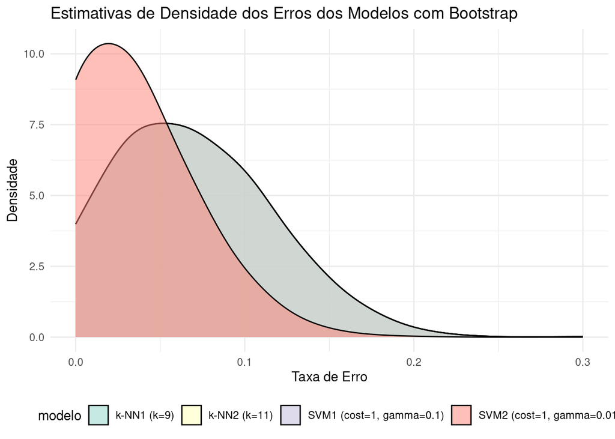

```r
#criando estimativas de densidade KDE soprepostas para comparar as distribuições
ggplot(resultados_bootstrap, aes(x = erro, fill = modelo)) +
  geom_density(alpha = 0.5,bw=0.02) +
  labs(title = "Estimativas de Densidade dos Erros dos Modelos com Bootstrap", x = "Taxa de Erro", y = "Densidade") +
  theme_minimal() +
  scale_fill_brewer(palette = "Set3") +
  theme(legend.position = "bottom")
```

**Análise da Tarefa 2.2:**

Podemos observar pelo gráfico que o modelo SVM2 apresenta menor mediana e média de erro, além disso, seu intervalo de confiança é mais estreito, indicando maior estabilidade. Já os modelos k-NN e o SVM1, apesar de apresentarem baixos erros médios, possuem intervalos de confiança mais amplos, sugerindo maior variabilidade em suas performances.

### 2.3 Análise de Ranking dos Modelos

```r
# 1. Calcular os rankings para cada amostra bootstrap
resultados_com_ranking <- resultados_bootstrap %>%
  group_by(id_bootstrap) %>%
  mutate(ranking = rank(erro, ties.method = "random")) %>%
  ungroup()

# 2. Criar tabela de frequência dos rankings
tabela_rankings <- resultados_com_ranking %>%
  group_by(modelo, ranking) %>%
  summarise(frequencia = n(), .groups = 'drop') %>%
  mutate(percentual = round(frequencia / n_bootstrap * 100, 1))

print(tabela_rankings)
```

```
# A tibble: 16 × 4
   modelo                    ranking frequencia percentual
   <chr>                       <int>      <int>      <dbl>
 1 SVM1 (cost=1, gamma=0.1)        1         90        9
 2 SVM1 (cost=1, gamma=0.1)        2        300       30
 3 SVM1 (cost=1, gamma=0.1)        3        306       30.6
 4 SVM1 (cost=1, gamma=0.1)        4        304       30.4
 5 SVM2 (cost=1, gamma=0.01)       1        729       72.9
 6 SVM2 (cost=1, gamma=0.01)       2         82        8.2
 7 SVM2 (cost=1, gamma=0.01)       3         96        9.6
 8 SVM2 (cost=1, gamma=0.01)       4         93        9.3
 9 k-NN1 (k=9)                     1         83        8.3
10 k-NN1 (k=9)                     2        298       29.8
11 k-NN1 (k=9)                     3        293       29.3
12 k-NN1 (k=9)                     4        326       32.6
13 k-NN2 (k=11)                    1         98        9.8
14 k-NN2 (k=11)                    2        320       32
15 k-NN2 (k=11)                    3        305       30.5
16 k-NN2 (k=11)                    4        277       27.7
```

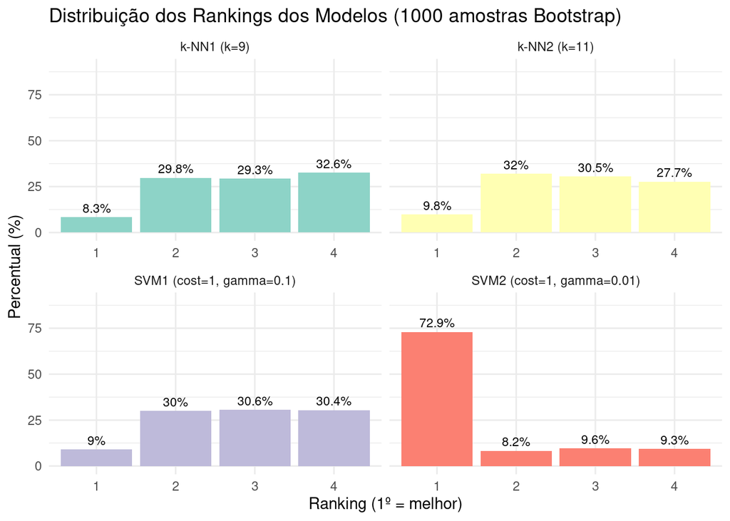

```r
# 3. Gráfico de barras mostrando a distribuição dos rankings
ggplot(tabela_rankings, aes(x = factor(ranking), y = percentual, fill = modelo)) +
  geom_bar(stat = "identity", position = "dodge") +
  facet_wrap(~ modelo, scales = "free_x") +
  labs(
    title = "Distribuição dos Rankings dos Modelos (1000 amostras Bootstrap)",
    x = "Ranking (1º = melhor)",
    y = "Percentual (%)",
    fill = "Modelo"
  ) +
  theme_minimal() +
  theme(legend.position = "none") +
  scale_fill_brewer(palette = "Set3") +
  scale_y_continuous(limits = c(0, 90)) +
  geom_text(aes(label = paste0(percentual, "%")),
            position = position_dodge(width = 0.9),
            vjust = -0.5, size = 3)
```

```r
# 4. Tabela resumo das performances por ranking
resumo_rankings <- tabela_rankings %>%
  group_by(modelo) %>%
  summarise(
    primeiro_lugar = sum(frequencia[ranking == 1]),
    segundo_lugar = sum(frequencia[ranking == 2]),
    terceiro_lugar = sum(frequencia[ranking == 3]),
    quarto_lugar = sum(frequencia[ranking == 4]),
    .groups = 'drop'
  ) %>%
  mutate(
    perc_primeiro = round(primeiro_lugar / n_bootstrap * 100, 1),
    perc_segundo = round(segundo_lugar / n_bootstrap * 100, 1),
    perc_terceiro = round(terceiro_lugar / n_bootstrap * 100, 1),
    perc_quarto = round(quarto_lugar / n_bootstrap * 100, 1)
  )

print(resumo_rankings)
```

```
# A tibble: 4 × 9
  modelo  primeiro_lugar segundo_lugar terceiro_lugar quarto_lugar perc_primeiro
  <chr>            <int>         <int>          <int>        <int>         <dbl>
1 SVM1 (…             90           300            306          304           9
2 SVM2 (…            729            82             96           93          72.9
3 k-NN1 …             83           298            293          326           8.3
4 k-NN2 …             98           320            305          277           9.8
# ℹ 3 more variables: perc_segundo <dbl>, perc_terceiro <dbl>,
#   perc_quarto <dbl>
```

```r
# 5. Calcular a proporção de vezes que cada modelo foi o melhor (rank 1)
proporcao_primeiro_lugar <- tabela_rankings %>%
  filter(ranking == 1) %>%
  select(modelo, percentual) %>%
  arrange(desc(percentual))

print(proporcao_primeiro_lugar)
```

```
# A tibble: 4 × 2
  modelo                    percentual
  <chr>                          <dbl>
1 SVM2 (cost=1, gamma=0.01)       72.9
2 k-NN2 (k=11)                     9.8
3 SVM1 (cost=1, gamma=0.1)         9
4 k-NN1 (k=9)                      8.3
```

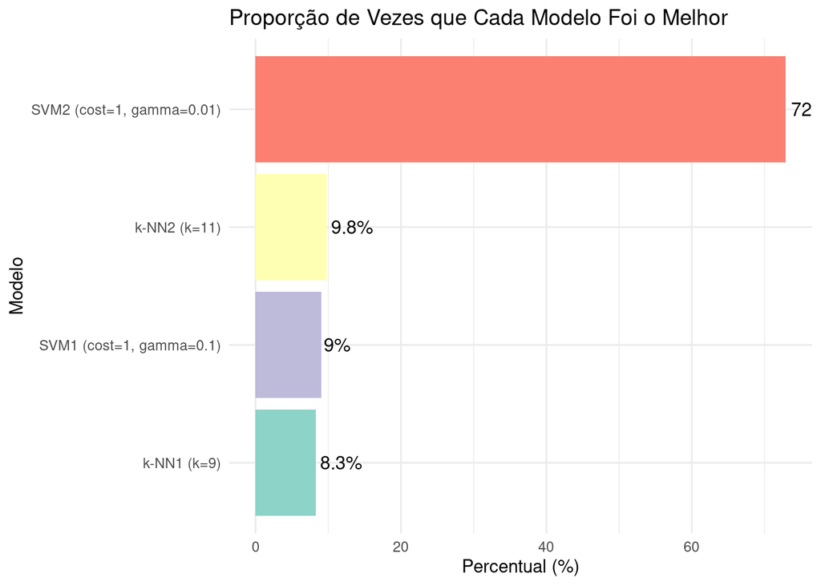

```r
# Gráfico de barras mostrando apenas os primeiros lugares
ggplot(proporcao_primeiro_lugar, aes(x = reorder(modelo, percentual), y = percentual, fill = modelo)) +
  geom_bar(stat = "identity") +
  coord_flip() +
  labs(
    title = "Proporção de Vezes que Cada Modelo Foi o Melhor",
    x = "Modelo",
    y = "Percentual (%)",
    fill = "Modelo"
  ) +
  theme_minimal() +
  scale_fill_brewer(palette = "Set3") +
  geom_text(aes(label = paste0(percentual, "%")),
            hjust = -0.1, size = 4) +
  theme(legend.position = "none")
```

**Análise da Tarefa 2.3:**

Com base na distribuição dos rankings, há um vencedor claro e inequívoco. O modelo SVM2 (cost=1, gamma=0.01) demonstra uma performance dominante, concentrando a maioria de seus resultados na primeira posição do ranking. Enquanto isso, os outros três modelos (k-NN1, k-NN2 e SVM1) apresentam distribuições muito semelhantes entre si, com suas performances espalhadas pelas posições intermediárias e piores (rankings 2, 3 e 4), e raramente alcançando o primeiro lugar. Essa nítida separação entre a performance do SVM2 e a dos demais modelos o estabelece como o vencedor.

A proporção de vezes que cada modelo foi o melhor (obteve o rank 1) quantifica essa dominância. Os cálculos, baseados nas 1000 amostras de bootstrap e visualizados no gráfico de barras, são os seguintes:

$EP=\sqrt{\frac{0,5\times0,5}{1000}}=0,0158$

Portanto, pensando em uma confiança de 99% ($z=2,576$), o intervalo de confiança para a proporção de vezes que o SVM2 foi o melhor seria: $(0,72 \pm 0,0406)$. Ou seja, adicionando cerca de 4% às estimativas, ainda o modelo SVM2 ainda estaria muito longe do outro.

## Parte 3: Síntese e Pensamento Crítico

**a) “…qual dos dois novos ‘melhores’ modelos SVM é superior ao outro?”**

Nossa expectativa é que a **confiança estatística para determinar qual dos dois novos “melhores” modelos SVM (encontrados na busca refinada) é superior ao outro provavelmente diminuiria, ou, na melhor das hipóteses, permaneceria similar, mas ainda assim baixa.**

- **Justificativa (Distribuições de Erro):**

Após um ajuste fino, os dois melhores modelos SVM tenderiam a se tornar bem parecidos em seu desempenho real. Ao testá-los com o Bootstrap, a variação natural do método provavelmente criaria uma sobreposição nas estimativas de erro causada pelo aumento da variabilidade na tentativa de diminuir o viés (overfiting). Na prática, ficaria difícil dizer se a pequena vantagem de um modelo seria uma melhoria real ou apenas ruído estatístico, fruto do acaso na amostragem. Por fim, para que as estimativas do intervalo de confiança não se toquem, provavelmente teríamos de diminuir a confiança estatística.

- **Justificativa (Distribuições de Ranking):**

Da mesma forma, se os dois modelos SVM refinados têm desempenhos quase idênticos, suas posições no ranking (1º ou 2º entre eles) em cada amostra Bootstrap seriam quase aleatórias ou altamente instáveis. Em muitas amostras Bootstrap, o modelo A poderia ser ligeiramente melhor, e em outras, o modelo B. Isso resultaria em distribuições de ranking onde ambos os modelos aparecem frequentemente como o “melhor” entre eles, sem que um domine claramente o outro. Consequentemente, a proporção de vezes que um modelo específico é classificado como superior ao outro não seria significativamente diferente de 50%, indicando baixa confiança na superioridade de um sobre o outro.

**b) “…se os ‘melhores’ modelos SVM são superiores aos ‘melhores’ modelos k-NN?”**

Nossa expectativa é que a **confiança estatística de que os “melhores” modelos SVM (da busca refinada) são superiores aos “melhores” modelos k-NN (identificados anteriormente) provavelmente permaneceria alta ou poderia até aumentar ligeiramente.**

- **Justificativa (Distribuições de Erro):** A busca refinada para SVM visa otimizar ainda mais um modelo que, presumivelmente (com base nos resultados da Tarefa 1.4 e 2.3 onde SVM2 foi superior), já apresentava um desempenho competitivo ou superior aos modelos k-NN. Se o melhor SVM da busca ampla já era superior ao melhor k-NN, espera-se que um SVM ainda mais refinado mantenha ou melhore ligeiramente essa performance. Portanto, a diferença nas taxas de erro médias entre os novos SVMs e os k-NNs provavelmente continuaria substancial. As distribuições de erro estimadas pelo Bootstrap para os SVMs refinados e para os k-NNs ainda apresentariam uma separação clara, com pouca sobreposição, mantendo a confiança na superioridade dos SVMs. Se a busca refinada encontrar um SVM marginalmente melhor que o anterior, essa separação poderia até aumentar um pouco.
- **Justificativa (Distribuições de Ranking):** Considerando que os SVMs da busca refinada teriam um desempenho igual ou melhor que o melhor SVM da busca ampla (que já se mostrou superior aos k-NNs na análise de ranking da Tarefa 2.3), espera-se que eles continuem a ocupar consistentemente os rankings mais altos em comparação com os modelos k-NN na maioria das amostras Bootstrap. A proporção de vezes que os SVMs refinados seriam classificados como superiores aos k-NNs permaneceria elevada, sustentando a alta confiança estatística nessa superioridade. A busca refinada dos SVMs não alteraria fundamentalmente a performance relativa dos k-NNs, que já foram estabelecidos como inferiores.

**Em resumo:** A busca refinada provavelmente resultaria em modelos SVM com desempenhos tão similares entre si que seria difícil diferenciá-los estatisticamente. No entanto, se os SVMs já eram superiores aos k-NNs, essa relação de superioridade provavelmente seria mantida ou até reforçada pelos modelos SVM otimizados pela busca refinada.

## Dicas e Pontos de Atenção

## Desafio Opcional

Neste desafio, vamos refinar a busca em torno do melhor par (`cost = 1`, `gamma = 0.1`) encontrado na busca ampla, repetir o 5-fold CV, refazer o bootstrap e comparar os rankings.

### Definição da Nova Grade Refinada

```r
grid_svm_refinada <- expand.grid(
  cost  = c(1.0, 0.5, 1.5),
  gamma = c(0.10,0.05, 0,15)
)
print(grid_svm_refinada)
```

```
   cost gamma
1   1.0  0.10
2   0.5  0.10
3   1.5  0.10
4   1.0  0.05
5   0.5  0.05
6   1.5  0.05
7   1.0  0.00
8   0.5  0.00
9   1.5  0.00
10  1.0 15.00
11  0.5 15.00
12  1.5 15.00
```

### 5-Fold CV na Grade Refinada

```r
set.seed(2025)

# Reutilizamos os folds criados em task1.2
resultados_refinada <- data.frame()

for (i in 1:nrow(grid_svm_refinada)) {
  cost_i  <- grid_svm_refinada$cost[i]
  gamma_i <- grid_svm_refinada$gamma[i]
  erros_fold <- c()

  for (fold in folds) {
    treino_cv <- iris_treino[-fold, ]
    valid_cv  <- iris_treino[fold, ]

    m <- svm(
      Species ~ ., data = treino_cv,
      kernel = "radial",
      cost   = cost_i,
      gamma  = gamma_i
    )
    preds <- predict(m, newdata = valid_cv)
    erros_fold <- c(erros_fold, mean(preds != valid_cv$Species))
  }

  resultados_refinada <- rbind(
    resultados_refinada,
    data.frame(cost = cost_i, gamma = gamma_i, erro_cv = mean(erros_fold))
  )
}

resultados_refinada <- resultados_refinada %>% arrange(erro_cv)
print(resultados_refinada)
```

```
   cost gamma    erro_cv
1   1.0  0.10 0.04285714
2   1.0  0.05 0.04285714
3   0.5  0.05 0.04285714
4   1.5  0.05 0.04285714
5   0.5  0.10 0.05714286
6   1.5  0.10 0.05714286
7   1.0 15.00 0.41428571
8   1.5 15.00 0.41428571
9   0.5 15.00 0.45714286
10  1.0  0.00 0.50000000
11  0.5  0.00 0.50000000
12  1.5  0.00 0.50000000
```

```r
# Selecionar os dois melhores
top2_svm_refinada <- head(resultados_refinada, 2)
print(top2_svm_refinada)
```

```
  cost gamma    erro_cv
1    1  0.10 0.04285714
2    1  0.05 0.04285714
```

### Bootstrap com os Dois Novos SVMs e os Dois Melhores k-NN

```r
# Definir os dois novos modelos SVM refinados
svm_ref1 <- svm(Species ~ ., data = iris_treino,
                kernel = "radial",
                cost  = top2_svm_refinada$cost[1],
                gamma = top2_svm_refinada$gamma[1])
svm_ref2 <- svm(Species ~ ., data = iris_treino,
                kernel = "radial",
                cost  = top2_svm_refinada$cost[2],
                gamma = top2_svm_refinada$gamma[2])

# Reusar amostras bootstrap criadas em task2.1_bootstrap_samples
resultados_boot_ref <- data.frame()

for (i in 1:n_bootstrap) {
  amostra <- amostras_bootstrap[[i]]

  pred_s1  <- predict(svm_ref1, newdata = amostra)
  pred_s2  <- predict(svm_ref2, newdata = amostra)
  pred_k9  <- knn(iris_treino[,1:4], amostra[,1:4], iris_treino$Species, k = 9)
  pred_k11 <- knn(iris_treino[,1:4], amostra[,1:4], iris_treino$Species, k = 11)

  erros <- c(
    mean(pred_s1  != amostra$Species),
    mean(pred_s2  != amostra$Species),
    mean(pred_k9  != amostra$Species),
    mean(pred_k11 != amostra$Species)
  )

  modelos <- c(
    paste0("SVM_ref1 (cost=", top2_svm_refinada$cost[1],
           ", gamma=", top2_svm_refinada$gamma[1], ")"),
    paste0("SVM_ref2 (cost=", top2_svm_refinada$cost[2],
           ", gamma=", top2_svm_refinada$gamma[2], ")"),
    "k-NN1 (k=9)",
    "k-NN2 (k=11)"
  )

  resultados_boot_ref <- rbind(
    resultados_boot_ref,
    data.frame(id = i, modelo = modelos, erro = erros)
  )
}

# Ranking para cada bootstrap
rank_ref <- resultados_boot_ref %>%
  group_by(id) %>%
  mutate(ranking = rank(erro, ties.method = "random")) %>%
  ungroup()

# Frequência de rank 1
prop_ref <- rank_ref %>%
  filter(ranking == 1) %>%
  count(modelo) %>%
  mutate(pct = round(n / n_bootstrap * 100, 1)) %>%
  arrange(desc(pct))
print(prop_ref)
```

```
# A tibble: 4 × 3
  modelo                            n   pct
  <chr>                         <int> <dbl>
1 SVM_ref2 (cost=1, gamma=0.05)   719  71.9
2 k-NN2 (k=11)                     99   9.9
3 SVM_ref1 (cost=1, gamma=0.1)     91   9.1
4 k-NN1 (k=9)                      91   9.1
```

### Comparação e Conclusão

**Proporção de rank 1 em 1000 amostras Bootstrap**

[output not shown]

- **Expectativa:** manter ou aumentar a confiança de que SVMs superam k-NNs.
- **Observação:** SVM_ref₂ obteve **71.9 %** das vezes, enquanto cada k-NN ficou em torno de **9–10 %**.
- **Conclusão:** confirma-se plenamente: o SVM refinado permanece muito acima dos k-NNs, com ampla margem estatística.